# PROJECT 1: UNSUPERVISED LEARNING

### 6.1.2 Clusplot

For this reason, we make a plot to visualize our clustered data in a 2D PCA space, with points representing countries and colors indicating the clusters.

[output not shown]

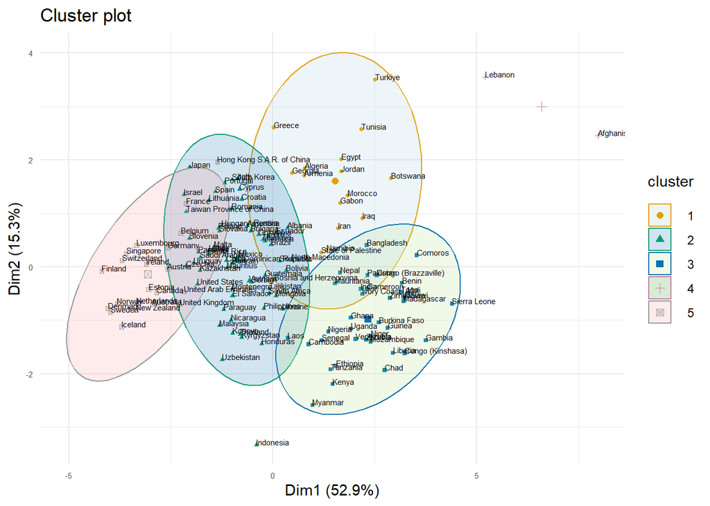

```r
# clusplot
#options(repr.plot.width = 15, repr.plot.height = 6)


fviz_cluster(fit, data = data2, geom = c("point"),ellipse.type = 'norm', pointsize=1)+
  theme_minimal()+geom_text(label=country_names,hjust=0, vjust=0,size=2,check_overlap = F)+scale_fill_brewer(palette="Paired")
```

[output not shown]

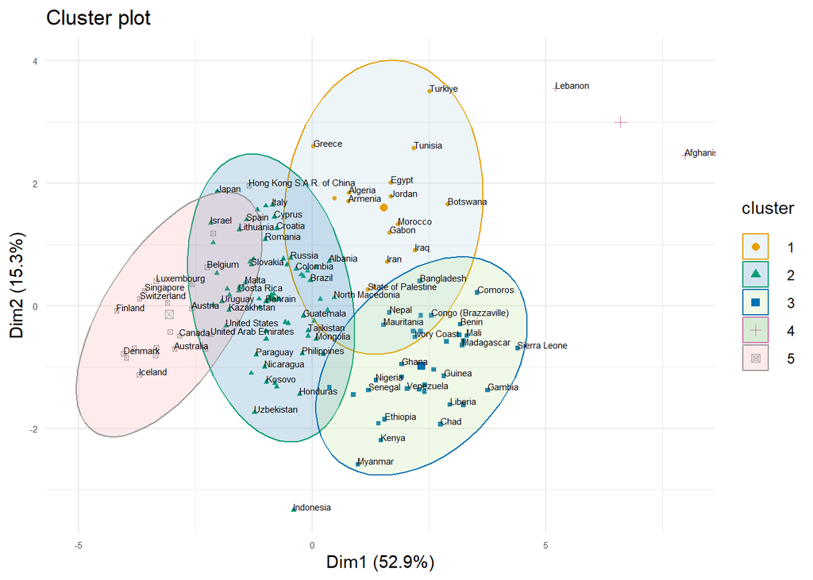

```r
# Let's make another plot with check_overlap = T, which is not going to display all countries, but it will more understandable

fviz_cluster(fit, data = data2, geom = c("point"),ellipse.type = 'norm', pointsize=1)+
  theme_minimal()+geom_text(label=country_names,hjust=0, vjust=0,size=2,check_overlap = T)+scale_fill_brewer(palette="Paired")
```

[output not shown]

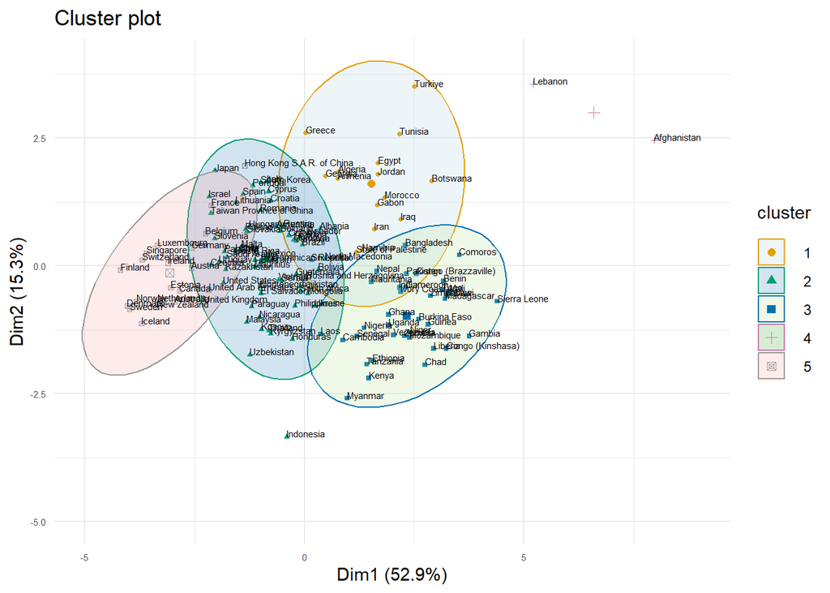

```r
# Make a little zoom
fviz_cluster(fit, data = data2, geom = c("point"),ellipse.type = 'norm', pointsize=1)+
  theme_minimal()+geom_text(label=country_names,hjust=0, vjust=0,size=2,check_overlap = F)+scale_fill_brewer(palette="Paired")  + coord_cartesian(xlim = c(-5, 9), ylim = c(-5, 4))
```

We need to remember the interpretation of the PCs. PC1 represent the “unhapiness of the countries” PC2 decreases with “Generosity” and “PositiveAffect” while it increases with “LogGDP” and ” HLE”.

In cluster 5, the red one, all variables positively contribute to the cluster except from “NegativeAffect” and “PerceptionsCorruption”. So, in this cluster we have the happiest and with better situation countries as Finland.

On the other hand, cluster 4 is the oppostite, as all variables negatively contribute to the cluster except from “NegativeAffect” and “PerceptionsCorruption”. So, in this cluster we have the unhappiest and with worse situation countries as Afghanistan

An alternative approach is to leverage the eclust function provided by the factoextra package. This function offers a wide range of clustering methods (such as k-means, pam, hierarchical clustering, and more), as well as various distance metrics and linkage methods to suit your specific clustering needs.

```r
data_name = data2
rownames(data_name) <- country_names
fit.kmeans <- eclust(data_name, "kmeans", stand=TRUE, k=5)
```

[output not shown]

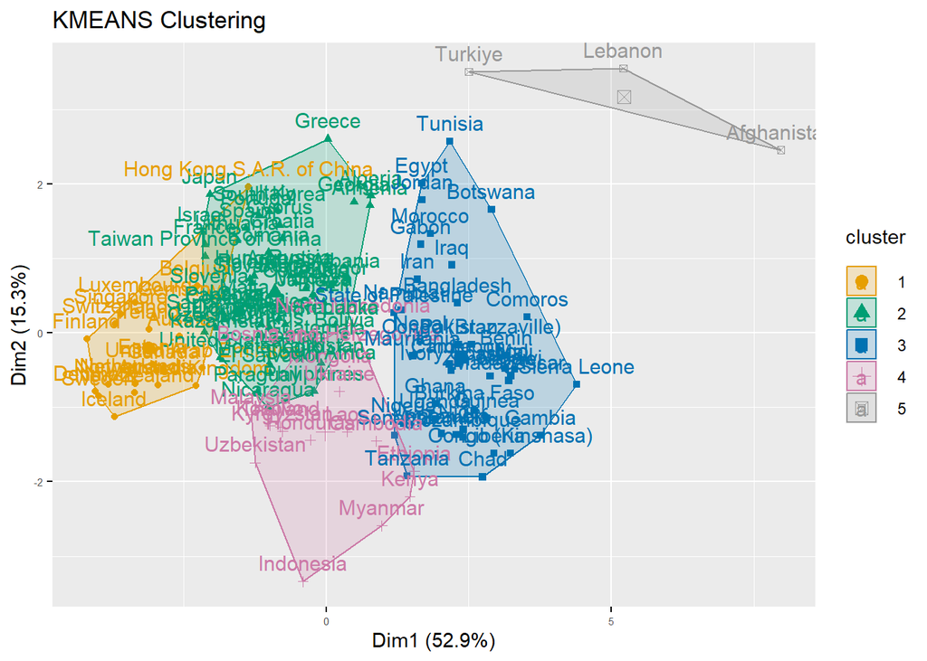

### 6.1.3 Silhouette plot

The silhouette plot is a graphical representation of the silhouette coefficients for each data point in the clusters ( measure of how similar a data point is to its own cluster compared to other clusters). It can help you assess the quality of the clustering by visualizing how well-separated and consistent the clusters are.

A high silhouette coefficient suggests a good cluster assignment. A silhouette coefficient near 0 suggests that the data point is on or very close to the decision boundary between two neighboring clusters. A negative silhouette coefficient indicates that the data point may have been assigned to the wrong cluster.

[output not shown]

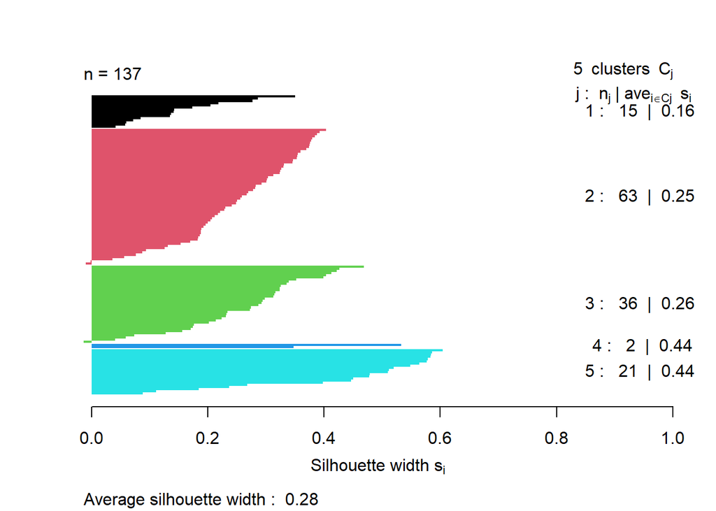

```r
# Distances between the points and the clusters
d <- dist(scale(data2), method="euclidean")
sil = silhouette(groups, d)
plot(sil, col=1:5, main="", border=NA)
```

```r
summary(sil)
```

```
## Silhouette of 137 units in 5 clusters from silhouette.default(x = groups, dist = d) :
##  Cluster sizes and average silhouette widths:
##        15        63        36         2        21
## 0.1586010 0.2516555 0.2636962 0.4403050 0.4429850
## Individual silhouette widths:
##     Min.  1st Qu.   Median     Mean  3rd Qu.     Max.
## -0.01365  0.18472  0.27654  0.27671  0.35510  0.60388
```

The cluster with the highest average silhouette width (0.44 C5) is the most well-separated and cohesive, while the cluster with the lowest average silhouette width (0.15 C1) is relatively less well-separated. The clusters with smaller average silhouette width (closer to 0) suggests that the data points within the cluster may be closer to the decision boundary between clusters.

```
##   cluster size ave.sil.width
## 1       1   20          0.46
## 2       2   56          0.24
## 3       3   41          0.23
## 4       4   17          0.16
## 5       5    3          0.28
```

[output not shown]

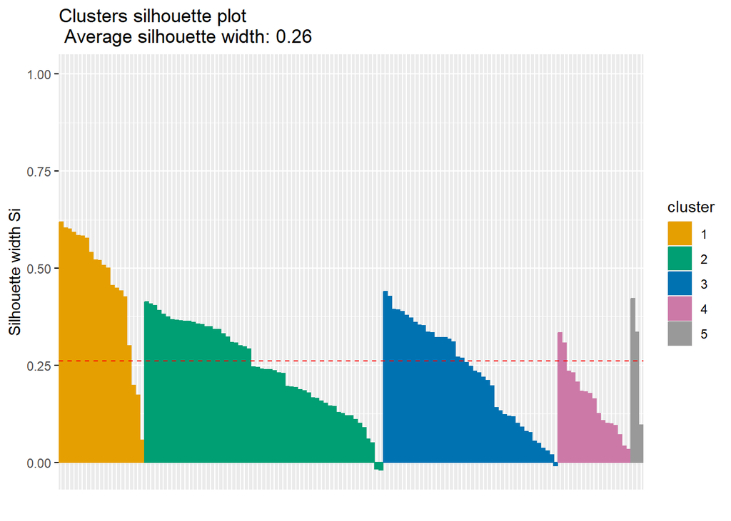

```r
# the same with factoextra
fviz_silhouette(fit.kmeans)
```

The negative values (close to -1) means that a data point is more similar to a neighboring cluster than its own, suggesting a potential misclassification.

### 6.1.4 Number of clusters

The choice of the number of clusters (k) is a crucial decision in clustering analysis, as it significantly impacts the quality and interpretability of the results.

The function **fviz_nbclust** will generate a plot or print a table showing the silhouette score for a range of values of k (the number of clusters). The optimal number of clusters is often associated with the peak or plateau in the silhouette score, where the clusters are well-separated and internally cohesive.

[output not shown]

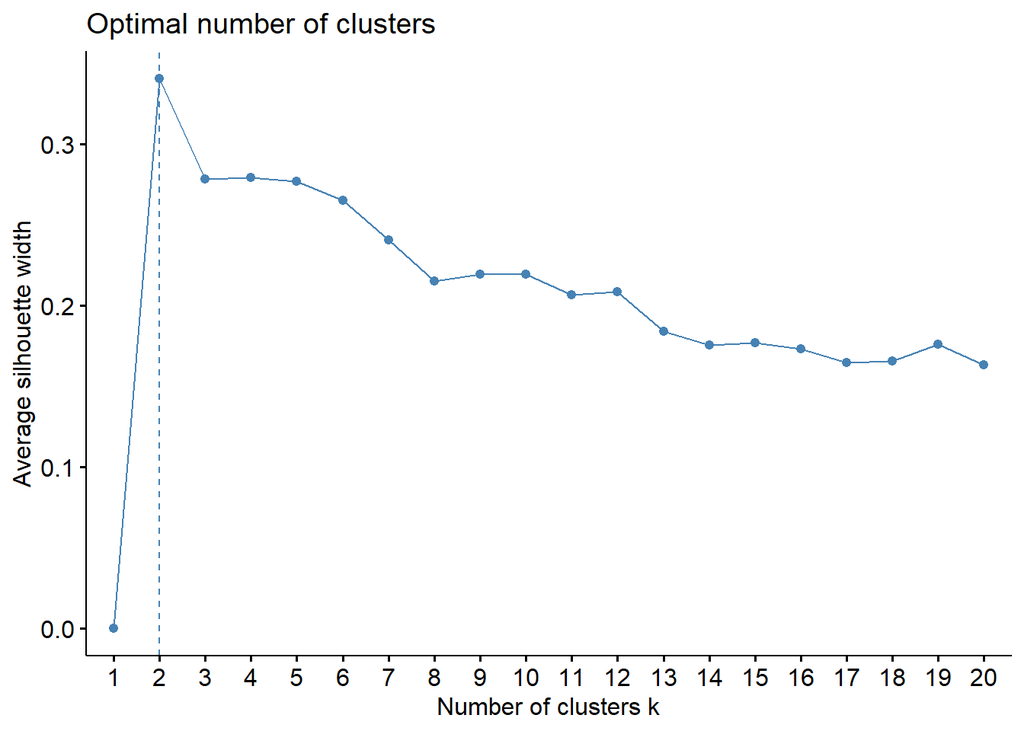

```r
fviz_nbclust(scale(data2), kmeans, method = 'silhouette', k.max = 20, nstart = 1000)
```

(2 clusters)

Within-Cluster Sum of Squares (WSS) criterion. The WSS measures the total variation within each cluster, and finding the “elbow point” in the plot of the WSS can help determine the optimal number of clusters.

[output not shown]

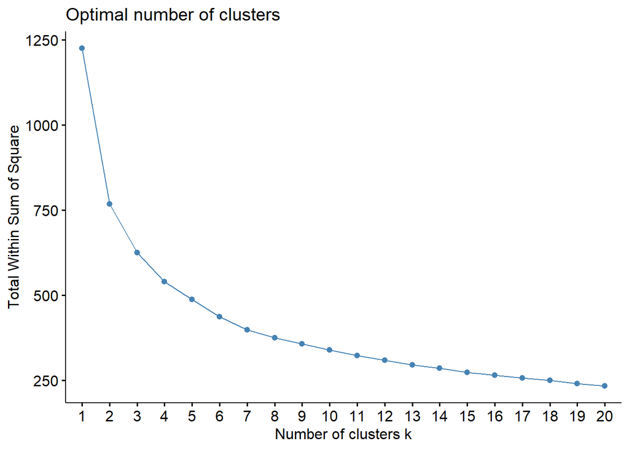

```r
fviz_nbclust(scale(data2), kmeans, method = 'wss', k.max = 20, nstart = 1000)
```

(2 or 3 clusters)

Gap Statistic and the reference distribution for a range of values of k (the number of clusters). The optimal number of clusters is often associated with the value of k that maximizes the Gap Statistic while taking into account the reference distribution.

[output not shown]

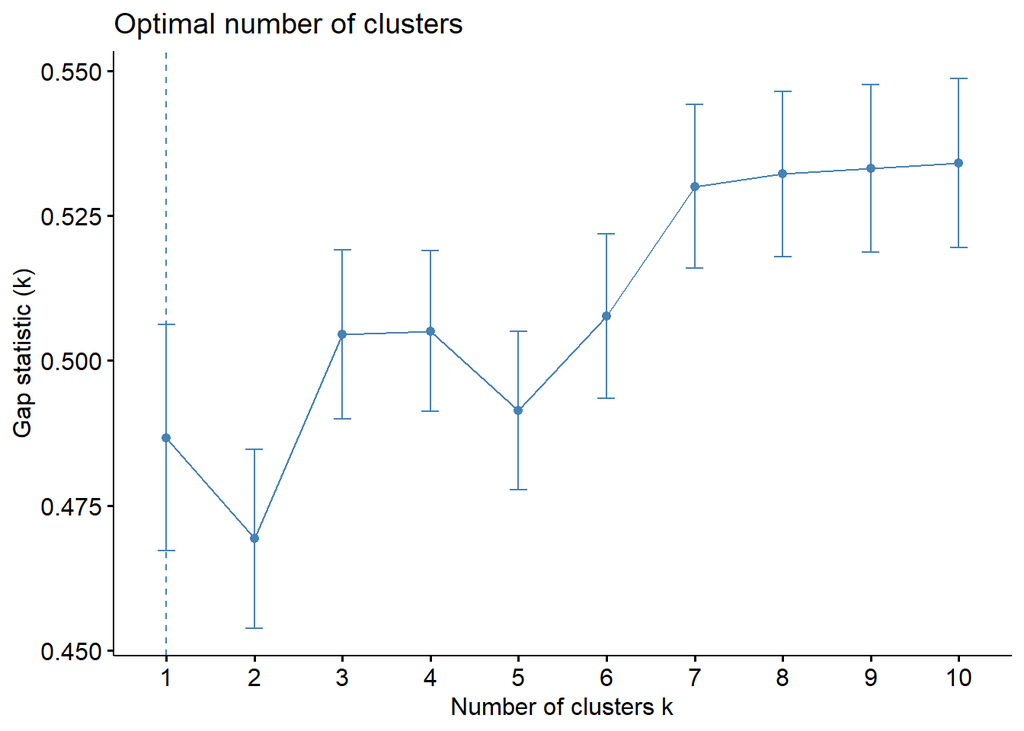

```r
fviz_nbclust(scale(data2), kmeans, method = 'gap_stat', k.max = 10, nstart = 100, nboot = 500)
```

Perform clustering with the best number of clusters. k = 2

[output not shown]

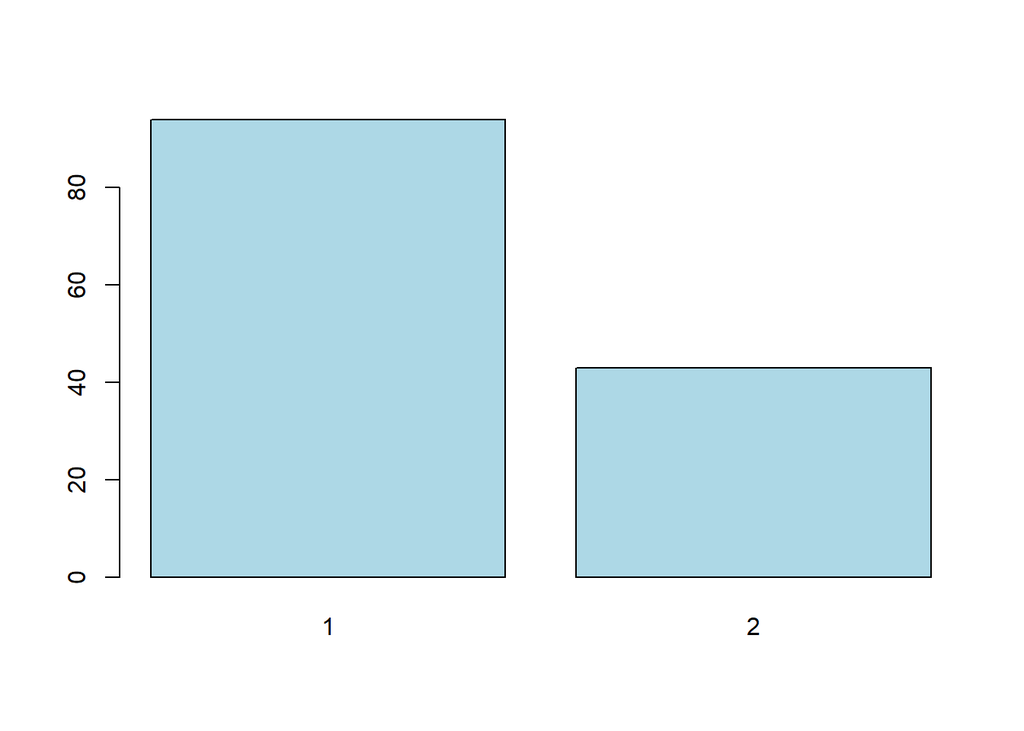

```r
fit2 = kmeans(data2, centers = 2, nstart = 25)

# Is the classification more balanced than before?
groups2 = fit2$cluster
barplot(table(groups2), col="#ADD8E6")
```

[output not shown]

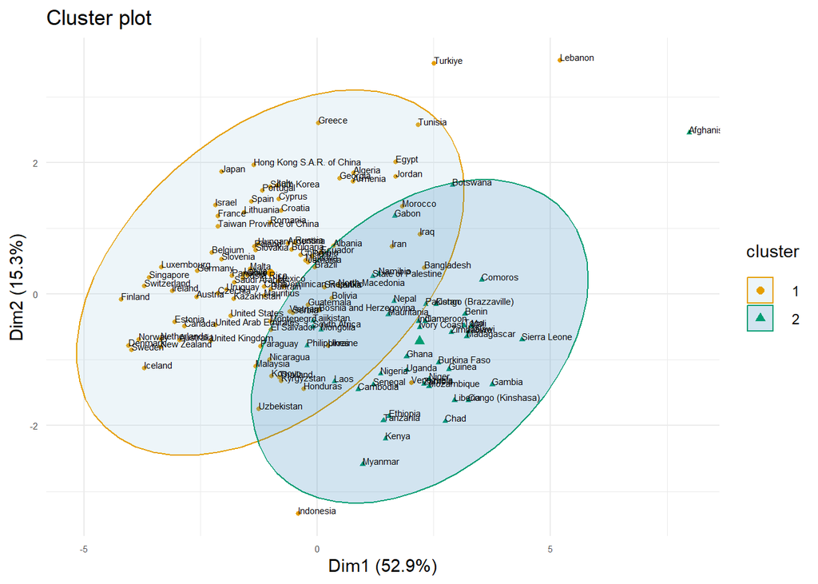

```r
# The clusplot can also be checked, observing that, indeed, a more balanced
# classification is obtained with the number of clusters equal to 2.
fviz_cluster(fit2, data = data2, geom = c("point"),ellipse.type = 'norm', pointsize=1)+
  theme_minimal()+geom_text(label=country_names,hjust=0, vjust=0,size=2,check_overlap = F)+scale_fill_brewer(palette="Paired")
```

## 6.2 PAM

Partitioning Around Medoids. The key difference between PAM and k-means is that PAM uses medoids as cluster centers, which are actual data points from the dataset (countries in our case), rather than the means (centroids) as in k-means. This makes PAM more robust to outliers and noise in the data.

[output not shown]

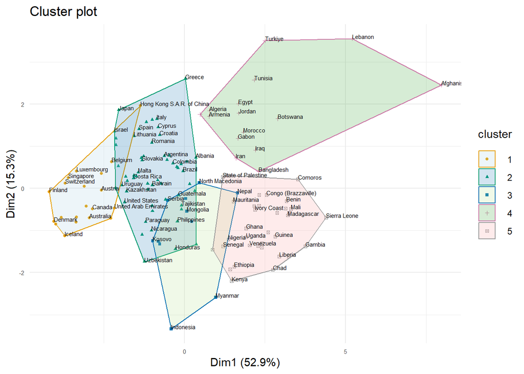

```r
fit.pam <- eclust(data2, "pam", stand=TRUE, k=5, graph=F)

fviz_cluster(fit.pam, data = data2, geom = c("point"), pointsize=1)+
  theme_minimal()+geom_text(label=country_names,hjust=0, vjust=0,size=2,check_overlap = T)+scale_fill_brewer(palette="Paired")
```

We obtain different cluster that the ones from k-means

### 6.2.1 Number clusters PAM

[output not shown]

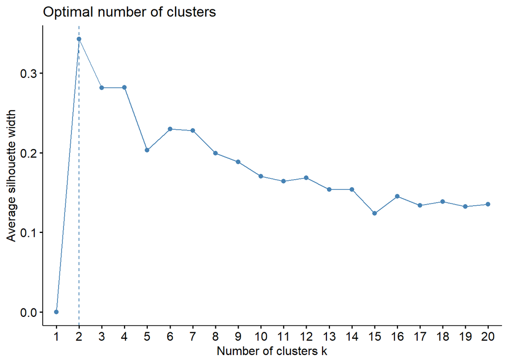

```r
fviz_nbclust(scale(data2), pam, method = 'silhouette', k.max = 20, nstart = 100)
```

(2 clusters)

[output not shown]

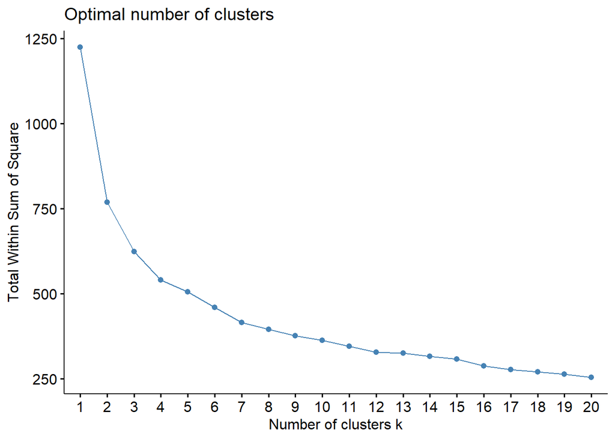

```r
fviz_nbclust(scale(data2), pam, method = 'wss', k.max = 20, nstart = 100)
```

(2 or 3 clusters)

Perform clustering with the best number of clusters. k = 2 PAM

[output not shown]

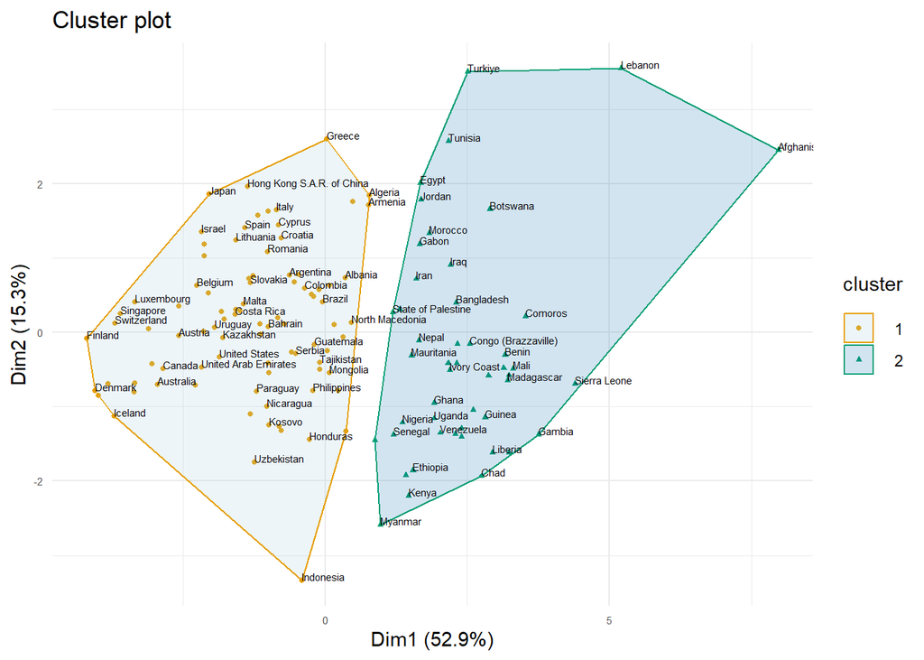

```r
fit.pam2 <- eclust(data2, "pam", stand=TRUE, k=2, graph=F)

fviz_cluster(fit.pam2, data = data2, geom = c("point"), pointsize=1)+
  theme_minimal()+geom_text(label=country_names,hjust=0, vjust=0,size=2,check_overlap = T)+scale_fill_brewer(palette="Paired")
```

#### 6.2.1.1 Similarity between clusters PAM - k-means

```r
# Computes the adjusted Rand index comparing two classifications.
# The closer to 1 the more agreement

# Similarity between for k = 5
adjustedRandIndex(fit.kmeans$cluster, fit.pam$clustering)
```

```
## [1] 0.7497828
```

```r
# Similarity between for k = 2
adjustedRandIndex(fit2$cluster, fit.pam2$clustering)
```

```
## [1] 0.6027743
```

They quite similar

### 6.2.2 Maps for clustering

```r
# Select here your favorite clustering tool
map = data.frame(country=country_names, value=fit.pam$clustering)
#map = data.frame(country=names, value=fit.kmeans$cluster)

#Convert the country code into iso3c using the function countrycode()
map$country = countrycode(map$country, 'country.name', 'iso3c')
#Create data object supporting the map
matched <- joinCountryData2Map(map, joinCode = "ISO3",
                               nameJoinColumn = "country")
```

```
## 136 codes from your data successfully matched countries in the map
## 1 codes from your data failed to match with a country code in the map
## 107 codes from the map weren't represented in your data
```

[output not shown]

[output not shown]

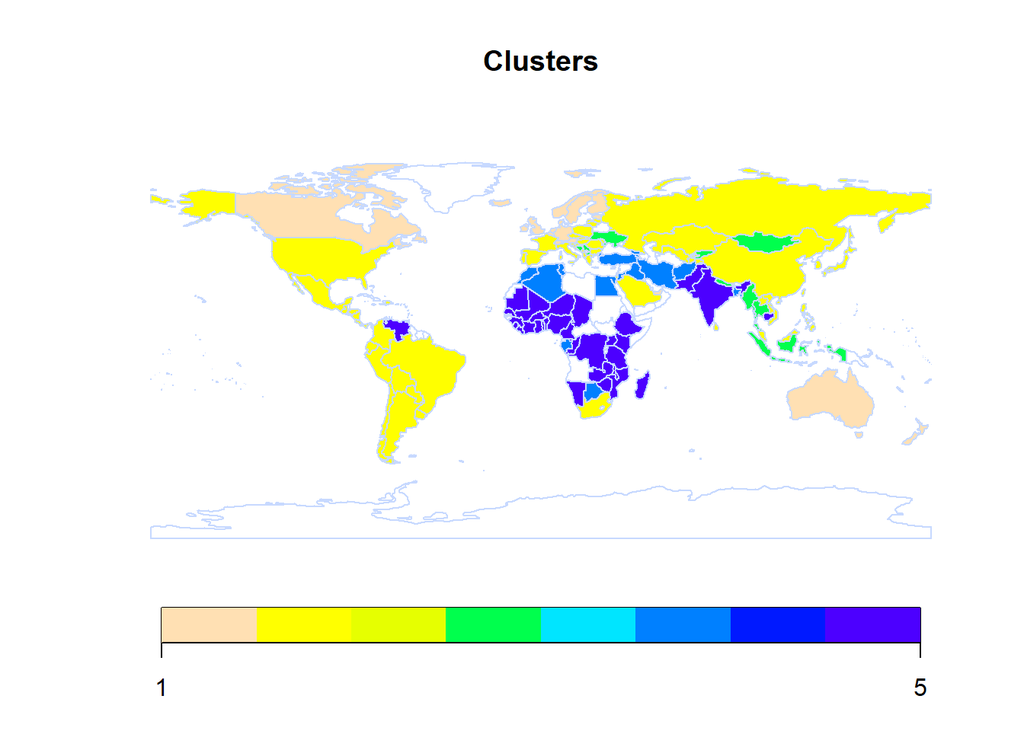

```r
#Draw the map
mapCountryData(matched,nameColumnToPlot="value",missingCountryCol = "white",
               borderCol = "#C7D9FF",
               catMethod = "pretty", colourPalette = "topo",
               mapTitle = c("Clusters"), lwd=1)
```

## 6.3 Kernel k-means

Kernel k-means is a variant of the traditional k-means clustering algorithm that uses kernel functions to perform clustering in a high-dimensional feature space. It is particularly useful when dealing with data that is not linearly separable in the original feature space. Kernel k-means allows for non-linear separation of clusters by implicitly mapping the data into a higher-dimensional space where linear separation may be possible.

```r
fit.ker <- kkmeans(as.matrix(data2), centers=5, kernel="rbfdot") # Radial Basis kernel (Gaussian)
```

```
## Using automatic sigma estimation (sigest) for RBF or laplace kernel
```

Retrieve the cluster centers from the kernel k-means clustering results

```r
centers(fit.ker)
```

```
##          [,1]      [,2]      [,3]     [,4]      [,5]         [,6]      [,7]
## [1,] 6.556867 10.796540 0.8883605 72.98875 0.7921294 -0.057399183 0.6029250
## [2,] 7.044259 10.894483 0.9208701 71.32505 0.8771523  0.093573462 0.4553478
## [3,] 6.069650 10.121002 0.8729529 69.39656 0.8136221 -0.033325582 0.7774809
## [4,] 4.496704  8.300552 0.6804989 59.05095 0.7253140  0.046531169 0.7756900
## [5,] 5.815083  9.753453 0.8509881 66.10464 0.8187466  0.003359769 0.7775715
##           [,8]      [,9]
## [1,] 0.6490884 0.2394319
## [2,] 0.7191553 0.2409622
## [3,] 0.6910953 0.2755464
## [4,] 0.6121222 0.3413712
## [5,] 0.6568087 0.2689462
```

Obtain the number of data points in each cluster,

```r
size(fit.ker)
```

```
## [1]  9 17 18 53 40
```

We see again unbalanced clusters

Obtain a WSS (within-cluster sum of squares for each cluster) for each cluster in the kernel k-means. Lower WSS values indicate that the data points within a cluster are closer to the cluster center, suggesting a more compact cluster.

```r
withinss(fit.ker)
```

```
## [1]  81128.38 144524.93 146794.68 310564.68 292806.16
```

[output not shown]

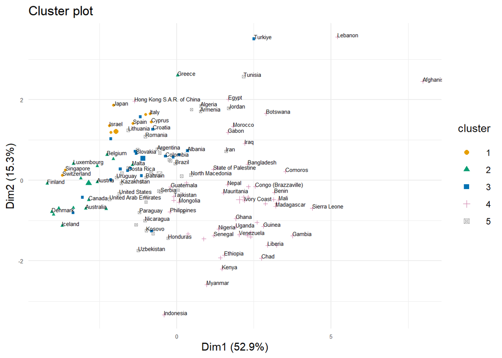

```r
object.ker = list(data = data2, cluster = fit.ker@.Data)
fviz_cluster(object.ker, geom = c("point"), ellipse=F,pointsize=1)+
  theme_minimal()+geom_text(label=country_names,hjust=0, vjust=0,size=2,check_overlap = T)+scale_fill_brewer(palette="Paired")
```

Again, we obtain very different clusters

## 6.4 Hierarchical clustering

```r
d = dist(scale(data2), method = "euclidean")
hc <- hclust(d, method = "ward.D2")
```

### 6.4.1 Plots

####**Dendogram**

[output not shown]

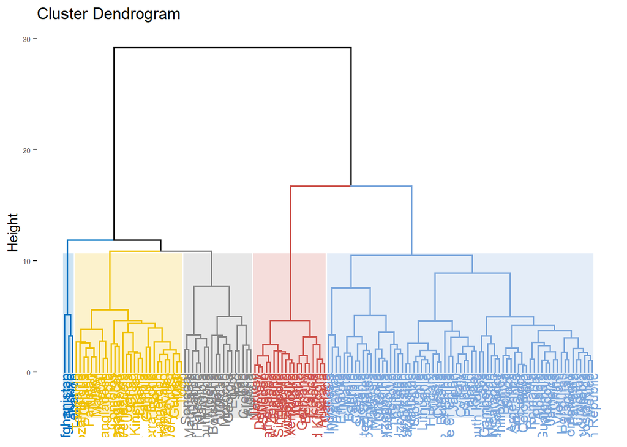

```r
hc$labels <- country_names

fviz_dend(x = hc,
          k=5,
          palette = "jco",
          rect = TRUE, rect_fill = TRUE,
          rect_border = "jco"  )
```

It is not clear as we have a lot of observations (countries)

####**Geographical map**

```r
groups.hc = cutree(hc, k = 5)

# Map our PCA index in a map:
map = data.frame(country=country_names, value=groups.hc)
#Convert the country code into iso3c using the function countrycode()
map$country = countrycode(map$country, 'country.name', 'iso3c')
#Create data object supporting the map
matched <- joinCountryData2Map(map, joinCode = "ISO3",
                               nameJoinColumn = "country")
```

```
## 136 codes from your data successfully matched countries in the map
## 1 codes from your data failed to match with a country code in the map
## 107 codes from the map weren't represented in your data
```

[output not shown]

[output not shown]

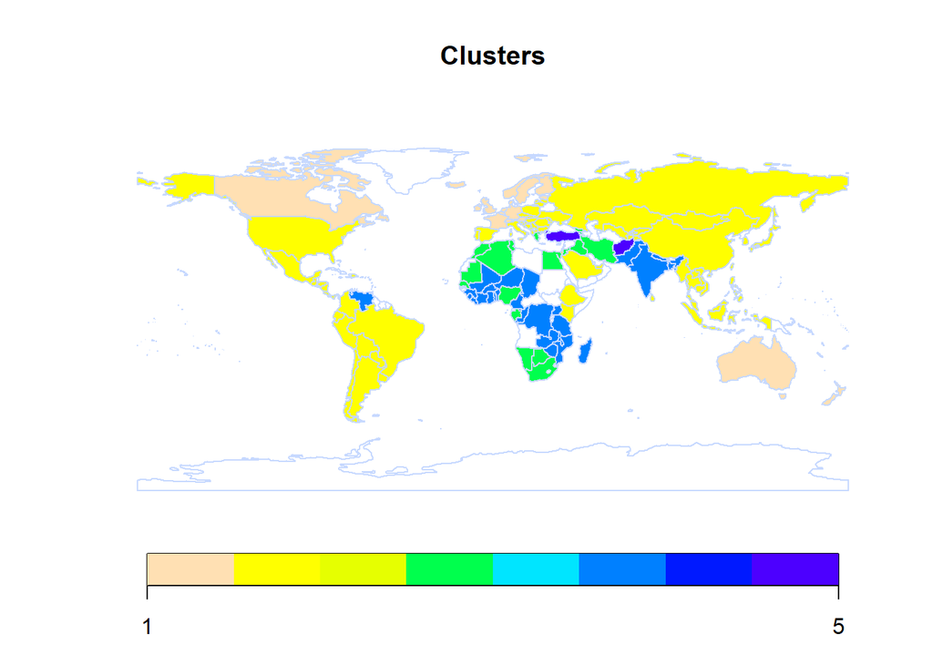

```r
#Draw the map

mapCountryData(matched,nameColumnToPlot="value",missingCountryCol = "white",
               borderCol = "#C7D9FF",
               catMethod = "pretty", colourPalette = "topo",
               mapTitle = c("Clusters"), lwd=1)
```

# 7 Heatmaps

The heatmap provides a visual representation of the similarities and differences between the rows and columns of your data. The color intensity in the heatmap represents the values of your scaled data, with darker colors indicating higher values.

[output not shown]

[output not shown]

[output not shown]

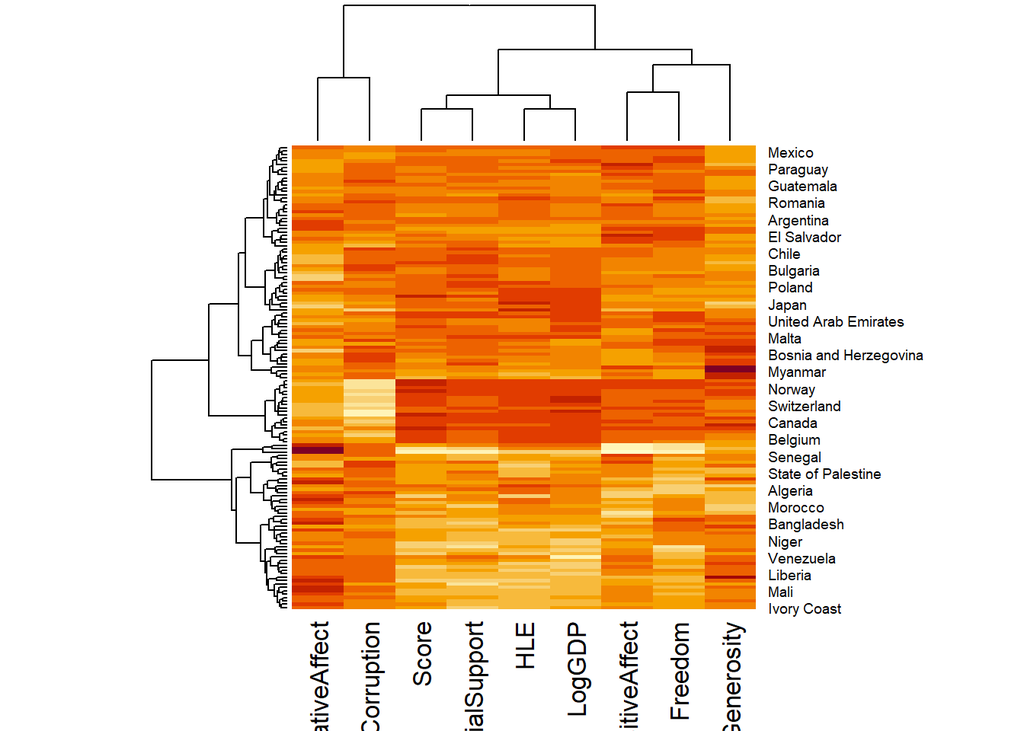

```r
heatmap(scale(data_name), scale = "none",
        distfun = function(x){dist(x, method = "euclidean")},
        hclustfun = function(x){hclust(x, method = "ward.D2")},
        cexRow = 0.7)
```

We see that we have 2 main groups of countries, Group 1 which has high values for “PerceptionsCorruption” and “NegativeAffect”. In this group we have countries with lower happiness as Iraq.

Group 2 with high values in the other variables. We have countries with higher happines as Spain and New Zealand.

```r
write.table(data2, "data_final.xls", sep=",")
```

# 8 CONCLUSIONS

Throughout this project, I have gained valuable insights into the significance of data cleaning techniques. By addressing issues such as missing values, duplicates, and irrelevant data points, I have ensured the data’s quality and reliability for subsequent analysis.

The utilization of dimensionality reduction methods, specifically Principal Component Analysis (PCA) and Factor Analysis (FA), has provided a deeper understanding of our dataset. These techniques have enabled me to uncover the relationships between variables, emphasizing the strong positive correlation between happiness levels and factors like GDP and Social Support, while revealing negative associations with Perceptions of Corruption and Negative Affect.

Clustering methodologies, including k-means, PAM, and kernel k-means, have proven instrumental in categorizing countries based on their unique characteristics. By forming these clusters, I have identified commonalities and disparities among countries, offering valuable insights into the potential drivers of happiness.

A notable outcome of this analysis is the identification of two primary country groups characterized by their “Perceptions of Corruption” and “Negative Affect” values. These groupings correspond to variations in happiness levels and have provided valuable geographical insights into the distribution of happiness across countries.

In summary, this project has highlighted the significance of data cleaning, dimensionality reduction, and clustering techniques in uncovering patterns and associations within the World Happiness dataset. These findings contribute to a deeper understanding of the factors influencing happiness and the geographic distribution of well-being, facilitating informed decision-making and further research in this area.